# Teoretická ACF

### MA(2) proces

Majme proces $X_t$ v tvare:
$$X_t = Z_t + \theta_1 Z_{t-1} + \theta_2 Z_{t-2}$$
Potom jeho ACF môže vyzerať aj takto:

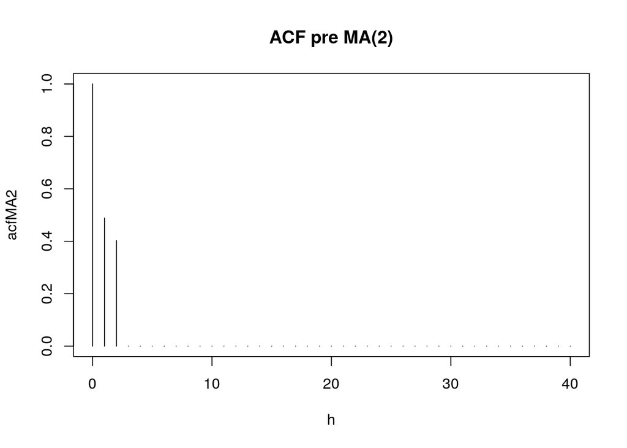

```r
h = 0:40
acfMA2 <- ARMAacf(ar = 0, ma = c(0.5,0.7),40)
plot(h, acfMA2, type = 'h', main = 'ACF pre MA(2)')
```

Vidíme dve nenulové hodnoty (okrem $h = 0$), čo nám napovedá, že je to MA(2) proces

### MA(6) proces

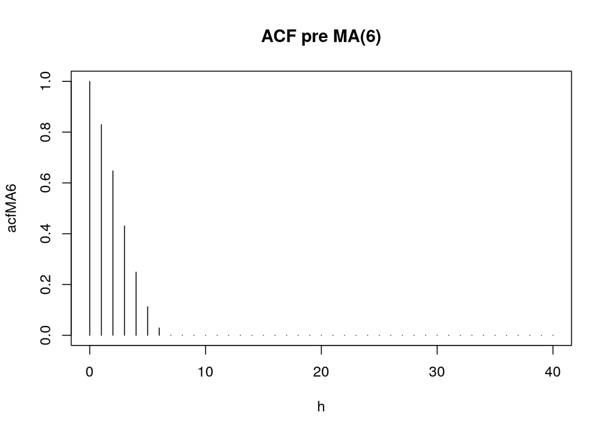

```r
h = 0:40
acfMA6 <- ARMAacf(ar = 0, ma = c(0.9,0.9,0.7,0.5,0.3, 0.1),40)
plot(h, acfMA6, type = 'h', main = 'ACF pre MA(6)')
```

### AR(1) proces

Majme proces $X_t$ v tvare:
$$X_t + \phi X_{t-1} = Z_t$$
Jeho ACF má tvar:
$$\varrho(h) = \phi^{|h|}$$
, kde $h\in \mathcal{Z}$ Potom jeho ACF môže vyzerať aj takto:

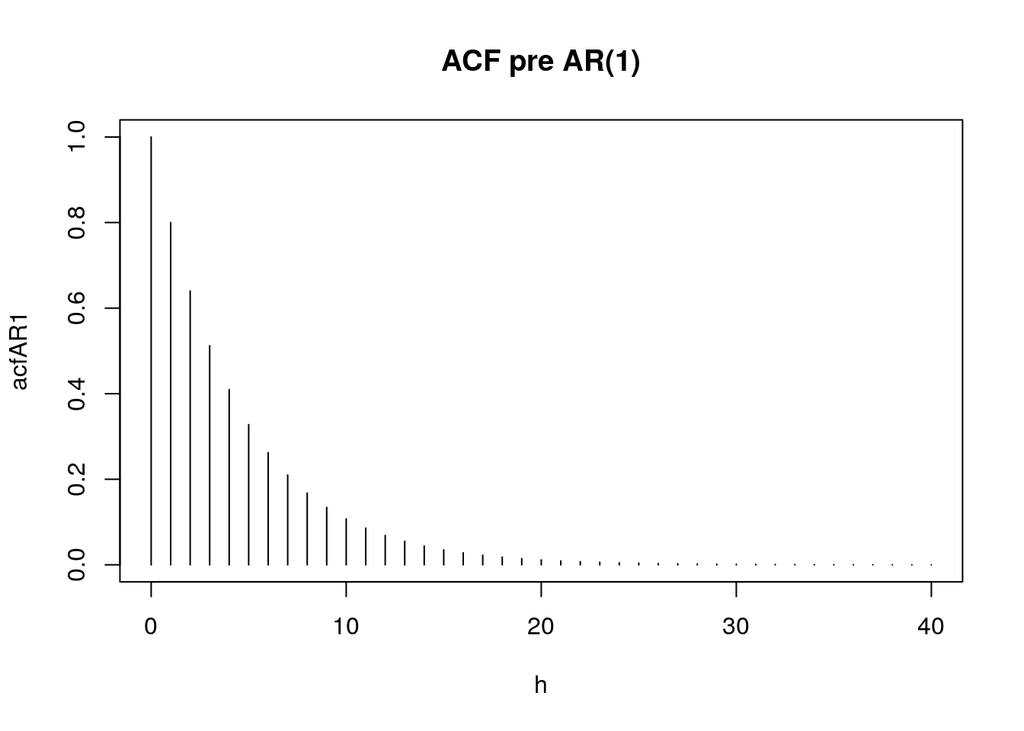

```r
h = 0:40
acfAR1 <- ARMAacf(ar =0.80, ma = 0,40)
plot(h, acfAR1, type = 'h', main = 'ACF pre AR(1)')
```

### AR(2) proces

Majme proces $X_t$ v tvare:
$$X_t + \phi_1 X_{t-1} + \phi_2 X_{t-2} = Z_t$$
Potom jeho ACF môže vyzerať aj takto:

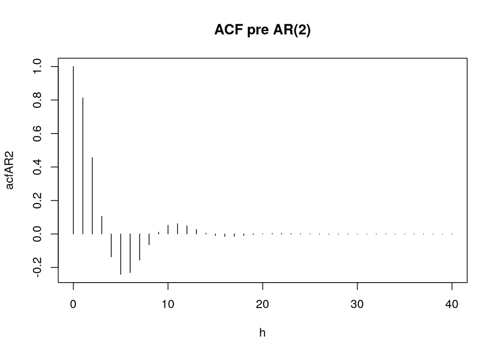

```r
h = 0:40
acfAR2 <- ARMAacf(ar =c(1.30, -0.6), ma = 0,40)
plot(h, acfAR2, type = 'h', main = 'ACF pre AR(2)')
```

Dochádza ku striedaniu pozitívnych a negatívnych korelácií.

### Iný AR(2) proces

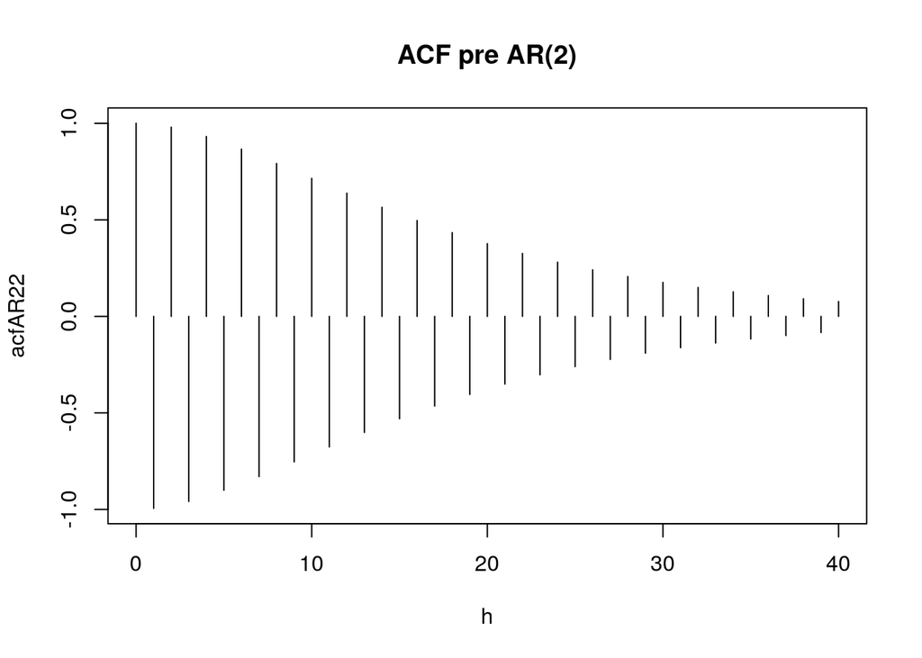

```r
h = 0:40
acfAR22 <- ARMAacf(ar =c(-1.80, -0.81), ma = 0,40)
plot(h, acfAR22, type = 'h', main = 'ACF pre AR(2)')
```

# PACF - Parciálna ACF

Jej význam je: $\alpha(0) = 1$ definitoricky a $\alpha(1) = Cor(X_{t+1},X_t)$, všeobecne:
$$\alpha(h) = Cor(X_{t+h}-\hat{X}_{t+h},X_{t}-\hat{X}_{t} )$$
Pre AR(p) platí, že $\alpha(h) = 0$ pre $h > p$. PACF ja ACF očistená o vplyv zložiek pred nimi…

## PACF pre AR(2)

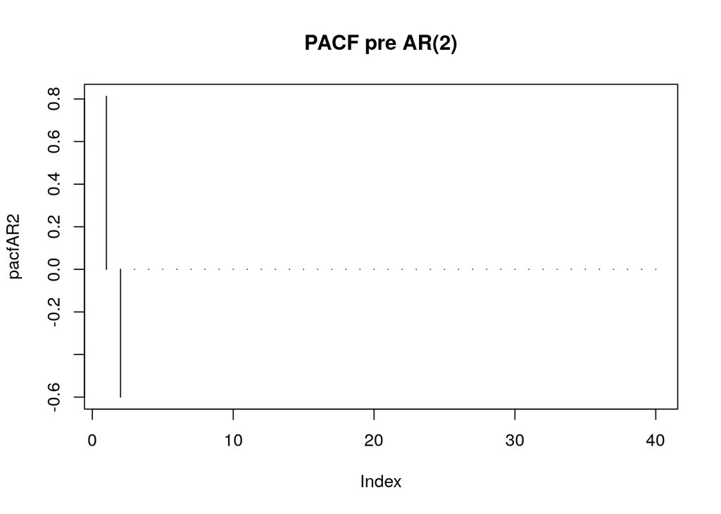

```r
h = 0:40
pacfAR2 <- ARMAacf(ar =c(1.30, -0.6), ma = 0,40, pacf = TRUE)
plot(pacfAR2, type = 'h', main = 'PACF pre AR(2)')
```

# ARMA(1,1)

Proces v tvare
$$X_t + \phi X_{t-1} = Z_t + \theta Z_{t-1}$$
Jej ACF má tvar:
$$\varrho(h) = \phi{h-1}\frac{\gamma(h)}{\gamma(0)}$$
.

## PACF pre ARMA(1,1)

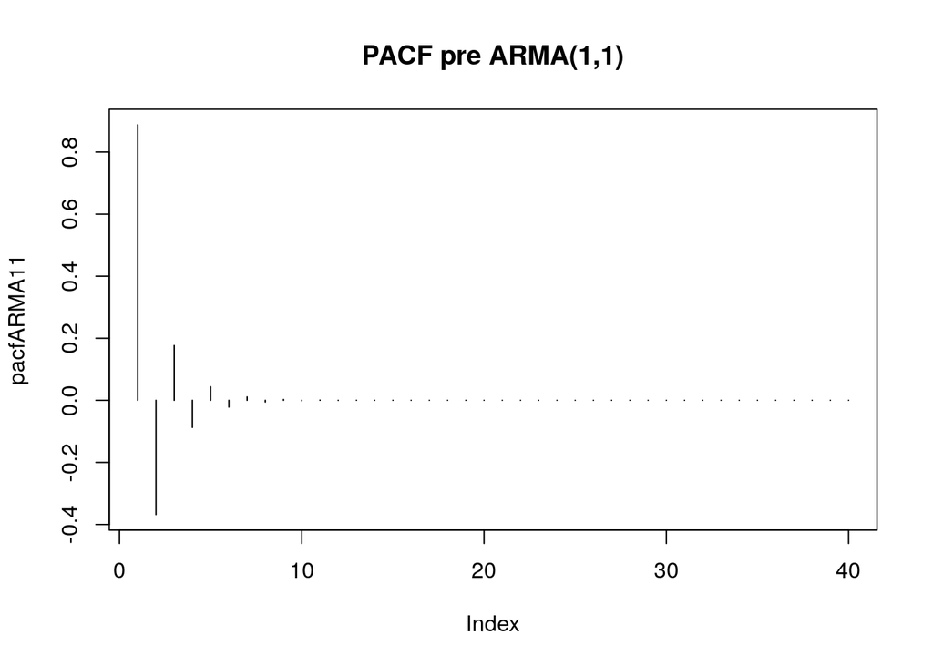

```r
h = 0:40
pacfARMA11 <- ARMAacf(ar =0.8, ma = 0.5 ,40, pacf = TRUE)
plot(pacfARMA11, type = 'h', main = 'PACF pre ARMA(1,1)')
```